# Prestige Bias

- Show All Code
- Hide All Code
- View Source

PSY 120L Reproducible Analysis Report

Author

Hermela Aklilu

Published

June 7, 2026

## Setup

This section loads the packages needed to clean the data, run analyses, and create tables/figures.

```r
knitr::opts_chunk$set(
  echo = TRUE,
  message = FALSE,
  warning = FALSE
)

options(stringsAsFactors = FALSE)

#| label: packages
#| echo: true
#| message: false
#| warning: false

library(tidyverse)
library(psych)
library(afex)
library(emmeans)
```

## Load Data

This section imports the Prestige Bias dataset and checks the first few rows and variable names to make sure the file loaded correctly.

```r
data <- read_csv("PrestigeBias - PrestigeBias.csv")
head(data)
```

```
# A tibble: 6 × 53
  StartDate   EndDate Duration (in seconds…¹ Finished RecordedDate Consent   MC1
  <chr>       <chr>                    <dbl>    <dbl> <chr>          <dbl> <dbl>
1 4/30/2026 … 4/30/2…                    195        1 4/30/2026 1…       2    NA
2 4/30/2026 … 4/30/2…                    168        1 4/30/2026 1…       2    NA
3 4/30/2026 … 4/30/2…                     36        1 4/30/2026 1…       2    NA
4 4/30/2026 … 4/30/2…                    371        1 4/30/2026 1…       2    NA
5 4/30/2026 … 4/30/2…                     56        1 4/30/2026 1…       2    NA
6 4/30/2026 … 4/30/2…                     43        1 4/30/2026 1…       2    NA
# ℹ abbreviated name: ¹`Duration (in seconds)`
# ℹ 46 more variables: SCSIntelligent <dbl>, SCSTrained <dbl>, SCSHonest <dbl>,
#   SCSTrust <dbl>, SCSExpert <dbl>, SCSSelf <dbl>, SCSHonorable <dbl>,
#   SCSInformed <dbl>, SCSMoral <dbl>, SCSCompetent <dbl>, SCSEthical <dbl>,
#   SCSsensitive <dbl>, SCSbright <dbl>, SCSgenuine <dbl>,
#   SCSunderstanding <dbl>, NFC_1 <dbl>, NFC_2 <dbl>, NFC_3 <dbl>, NFC_4 <dbl>,
#   NFC_5 <dbl>, NFC_6 <dbl>, TIS_1 <dbl>, TIS_2 <dbl>, TIS_3 <dbl>, …
```

```r
names(data)
```

```
 [1] "StartDate"
 [2] "EndDate"
 [3] "Duration (in seconds)"
 [4] "Finished"
 [5] "RecordedDate"
 [6] "Consent"
 [7] "MC1"
 [8] "SCSIntelligent"
 [9] "SCSTrained"
[10] "SCSHonest"
[11] "SCSTrust"
[12] "SCSExpert"
[13] "SCSSelf"
[14] "SCSHonorable"
[15] "SCSInformed"
```

[output cut: 38 more lines]

## Variable Preparation and Scale Construction

This section selects the variables needed for the study, including condition, demographics, source credibility items, need for cognition items, and trust in science items.

#### Define the Study Variable List

This section identifies the variables that will be used in the analyses, including the experimental condition and the scale items.

```r
study_vars <- c(
  "condition",
  "Gender",
  "Age",

  "SCSIntelligent", "SCSTrained", "SCSHonest", "SCSTrust", "SCSExpert", "SCSSelf", "SCSHonorable", "SCSInformed", "SCSMoral", "SCSMoral", "SCSCompetent", "SCSEthical", "SCSsensitive", "SCSbright", "SCSgenuine", "SCSunderstanding", # Sorce Credibility Scale items
  "NFC_1", "NFC_2", "NFC_3", "NFC_4", "NFC_5", "NFC_6", #Need for Cognition items
  "TIS_1", "TIS_2", "TIS_3", "TIS_4", "TIS_5", "TIS_6", "TIS_7", "TIS_8", "TIS_9","TIS_10", "TIS_11", "TIS_12", "TIS_13", "TIS_14","TIS_15", "TIS_16", "TIS_17", "TIS_18", "TIS_19", "TIS_20", "TIS_21" # Trust in Science items
)

length(study_vars)
```

```
[1] 46
```

#### Create the analysis dataset

This code creates a smaller dataset containing only the variables needed for the project.

```r
lab_data <- data[, study_vars]
names(lab_data)
```

```
 [1] "condition"        "Gender"           "Age"              "SCSIntelligent"
 [5] "SCSTrained"       "SCSHonest"        "SCSTrust"         "SCSExpert"
 [9] "SCSSelf"          "SCSHonorable"     "SCSInformed"      "SCSMoral"
[13] "SCSMoral"         "SCSCompetent"     "SCSEthical"       "SCSsensitive"
[17] "SCSbright"        "SCSgenuine"       "SCSunderstanding" "NFC_1"
[21] "NFC_2"            "NFC_3"            "NFC_4"            "NFC_5"
[25] "NFC_6"            "TIS_1"            "TIS_2"            "TIS_3"
[29] "TIS_4"            "TIS_5"            "TIS_6"            "TIS_7"
[33] "TIS_8"            "TIS_9"            "TIS_10"           "TIS_11"
[37] "TIS_12"           "TIS_13"           "TIS_14"           "TIS_15"
[41] "TIS_16"           "TIS_17"           "TIS_18"           "TIS_19"
[45] "TIS_20"           "TIS_21"
```

#### Prepare the dataset

This section cleans and formats the data to prepare it for analysis.

```r
summary(lab_data)
```

```
  condition             Gender           Age        SCSIntelligent
 Length:61          Min.   :1.000   Min.   :2.000   Min.   :1.000
 Class :character   1st Qu.:2.000   1st Qu.:2.000   1st Qu.:2.000
 Mode  :character   Median :2.000   Median :2.000   Median :4.000
                    Mean   :1.898   Mean   :2.441   Mean   :3.475
                    3rd Qu.:2.000   3rd Qu.:2.000   3rd Qu.:4.000
                    Max.   :4.000   Max.   :6.000   Max.   :7.000
                    NA's   :2       NA's   :2
   SCSTrained     SCSHonest        SCSTrust       SCSExpert        SCSSelf
 Min.   :1.00   Min.   :1.000   Min.   :1.000   Min.   :1.000   Min.   :2.000
 1st Qu.:3.00   1st Qu.:2.000   1st Qu.:3.000   1st Qu.:4.000   1st Qu.:4.000
 Median :4.00   Median :3.000   Median :4.000   Median :5.000   Median :4.000
 Mean   :4.18   Mean   :3.459   Mean   :4.246   Mean   :4.508   Mean   :4.492
 3rd Qu.:5.00   3rd Qu.:4.000   3rd Qu.:5.000   3rd Qu.:5.000   3rd Qu.:5.000
 Max.   :7.00   Max.   :7.000   Max.   :7.000   Max.   :7.000   Max.   :7.000

  SCSHonorable    SCSInformed       SCSMoral        SCSMoral
 Min.   :1.000   Min.   :1.000   Min.   :1.000   Min.   :1.000
 1st Qu.:3.000   1st Qu.:3.000   1st Qu.:3.000   1st Qu.:3.000
 Median :4.000   Median :4.000   Median :4.000   Median :4.000
 Mean   :3.672   Mean   :3.803   Mean   :3.721   Mean   :3.721
 3rd Qu.:4.000   3rd Qu.:5.000   3rd Qu.:4.000   3rd Qu.:4.000
 Max.   :7.000   Max.   :7.000   Max.   :7.000   Max.   :7.000

  SCSCompetent     SCSEthical     SCSsensitive     SCSbright       SCSgenuine
 Min.   :1.000   Min.   :1.000   Min.   :1.000   Min.   :1.000   Min.   :1.00
 1st Qu.:4.000   1st Qu.:4.000   1st Qu.:4.000   1st Qu.:2.000   1st Qu.:4.00
 Median :4.000   Median :4.000   Median :4.000   Median :4.000   Median :4.00
 Mean   :4.689   Mean   :4.475   Mean   :4.328   Mean   :3.639   Mean   :4.41
 3rd Qu.:6.000   3rd Qu.:6.000   3rd Qu.:5.000   3rd Qu.:5.000   3rd Qu.:5.00
 Max.   :7.000   Max.   :7.000   Max.   :7.000   Max.   :7.000   Max.   :7.00

 SCSunderstanding     NFC_1           NFC_2           NFC_3
 Min.   :2.000    Min.   :1.000   Min.   :1.000   Min.   :1.00
 1st Qu.:4.000    1st Qu.:2.000   1st Qu.:2.000   1st Qu.:2.00
 Median :4.000    Median :3.000   Median :3.000   Median :2.00
 Mean   :4.541    Mean   :2.733   Mean   :3.083   Mean   :2.55
 3rd Qu.:5.000    3rd Qu.:4.000   3rd Qu.:4.000   3rd Qu.:3.00
 Max.   :7.000    Max.   :5.000   Max.   :5.000   Max.   :5.00
                  NA's   :1       NA's   :1       NA's   :1
```

[output cut: 33 more lines]

```
 Min.   :1.000   Min.   :1.000   Min.   :1.000   Min.   :1.000
 1st Qu.:2.000   1st Qu.:2.000   1st Qu.:2.000   1st Qu.:2.000
 Median :2.000   Median :2.000   Median :2.000   Median :3.000
 Mean   :2.509   Mean   :2.509   Mean   :2.418   Mean   :2.655
 3rd Qu.:3.000   3rd Qu.:3.000   3rd Qu.:3.000   3rd Qu.:3.000
 Max.   :5.000   Max.   :5.000   Max.   :5.000   Max.   :5.000
 NA's   :6       NA's   :6       NA's   :6       NA's   :6
     TIS_21
 Min.   :1.000
 1st Qu.:1.000
 Median :2.000
 Mean   :1.964
 3rd Qu.:2.000
 Max.   :5.000
 NA's   :6
```

#### Label the experimental condition

Participants were assigned to either a high-prestige or low-prestige source condition. This step creates readable labels for those groups.

```r
lab_data<- lab_data[, !duplicated(names(lab_data))]
lab_data <- lab_data %>%
  filter(!is.na(condition)) %>%
  mutate(
    condition = factor(
      condition
    )
  )

lab_data %>%
  count(condition)
```

```
# A tibble: 2 × 2
  condition         n
  <fct>         <int>
1 high_prestige    30
2 low_prestige     31
```

#### Create participant ID

A unique participant ID is created so each participant can be tracked throughout the analyses.

```r
lab_data<- lab_data[, !duplicated(names(lab_data))]
lab_data <- lab_data %>%
  mutate(id = row_number())

lab_data %>% select(id) %>% head()
```

```
# A tibble: 6 × 1
     id
  <int>
1     1
2     2
3     3
4     4
5     5
6     6
```

#### Reverse-code scale items

Negatively worded items are reverse-coded so that higher scores consistently reflect higher levels of each construct.

```r
# Reverse-code selected items
lab_data <- lab_data %>%
  mutate(
    SCSIntelligentr  = 7 - SCSIntelligent,
    SCSHonestr  = 7 - SCSHonest,
    SCSHonorabler = 7 - SCSHonorable,
    SCSInformedr = 7 - SCSInformed,
    SCSMoralr = 7 - SCSMoral,
    SCSbrightr = 7 - SCSbright,
    NFC_3r = 5 - NFC_3,
    NFC_4r = 5 - NFC_4,
    TIS_1r = 5 - TIS_1,
    TIS_2r = 5 - TIS_2,
    TIS_3r = 5 - TIS_3,
    TIS_4r = 5 - TIS_4,
    TIS_6r = 5 - TIS_6,
    TIS_8r = 5 - TIS_8,
    TIS_13r = 5 - TIS_13,
    TIS_17r = 5 - TIS_17,
    TIS_18r = 5 - TIS_18,
    TIS_19r = 5 - TIS_19,
    TIS_20r = 5 - TIS_20,
    TIS_21r = 5 - TIS_21,
  )

# Compare original and reversed values
lab_data %>%
  select(SCSIntelligent, SCSIntelligentr) %>%
  head()
```

```
# A tibble: 6 × 2
  SCSIntelligent SCSIntelligentr
           <dbl>           <dbl>
1              7               0
2              1               6
3              4               3
4              2               5
5              1               6
6              4               3
```

#### Define scale items

This section specifies which survey items belong to each scale.

```r
# Define depression scale items
SCS_items <- c(
  "SCSIntelligentr", "SCSTrained", "SCSHonestr", "SCSTrust", "SCSExpert", "SCSSelf", "SCSHonorabler", "SCSInformedr", "SCSMoralr", "SCSCompetent", "SCSEthical", "SCSsensitive", "SCSbrightr", "SCSgenuine", "SCSunderstanding"
)

NFC_items <- c(
  "NFC_1", "NFC_2", "NFC_3r", "NFC_4r", "NFC_5", "NFC_6"
)

TIS_items <- c(
  "TIS_1r", "TIS_2r", "TIS_3r", "TIS_4r", "TIS_5", "TIS_6r", "TIS_7", "TIS_8r", "TIS_9","TIS_10", "TIS_11", "TIS_12", "TIS_13r","TIS_14", "TIS_15", "TIS_16", "TIS_17r", "TIS_18r", "TIS_19r", "TIS_20r", "TIS_21r"
)



# Check that all items exist in dataset
setNames(SCS_items %in% names(lab_data), SCS_items)
```

```
 SCSIntelligentr       SCSTrained       SCSHonestr         SCSTrust
            TRUE             TRUE             TRUE             TRUE
       SCSExpert          SCSSelf    SCSHonorabler     SCSInformedr
            TRUE             TRUE             TRUE             TRUE
       SCSMoralr     SCSCompetent       SCSEthical     SCSsensitive
            TRUE             TRUE             TRUE             TRUE
      SCSbrightr       SCSgenuine SCSunderstanding
            TRUE             TRUE             TRUE
```

```r
setNames(NFC_items %in% names(lab_data), NFC_items)
```

```
 NFC_1  NFC_2 NFC_3r NFC_4r  NFC_5  NFC_6
  TRUE   TRUE   TRUE   TRUE   TRUE   TRUE
```

```r
setNames(TIS_items %in% names(lab_data), TIS_items)
```

```
 TIS_1r  TIS_2r  TIS_3r  TIS_4r   TIS_5  TIS_6r   TIS_7  TIS_8r   TIS_9  TIS_10
   TRUE    TRUE    TRUE    TRUE    TRUE    TRUE    TRUE    TRUE    TRUE    TRUE
 TIS_11  TIS_12 TIS_13r  TIS_14  TIS_15  TIS_16 TIS_17r TIS_18r TIS_19r TIS_20r
   TRUE    TRUE    TRUE    TRUE    TRUE    TRUE    TRUE    TRUE    TRUE    TRUE
TIS_21r
   TRUE
```

#### Compute scale score

This section creates overall scale scores by averaging the relevant items for source credibility, need for cognition, and trust in science.

```r
# Compute depression scale as the row mean of items
lab_data <- lab_data %>%
  mutate(
    SCS_scale = rowMeans(as.matrix(across(all_of(SCS_items))), na.rm = TRUE)
  )

lab_data <- lab_data %>%
  mutate(
    NFC_scale = rowMeans(as.matrix(across(all_of(NFC_items))), na.rm = TRUE)
  )
lab_data <- lab_data %>%
  mutate(
    TIS_scale = rowMeans(as.matrix(across(all_of(TIS_items))), na.rm = TRUE)
  )
# Check proportion of missing scale scores
mean(is.na(lab_data$SCS_scale))  # should be close to 0
```

```
[1] 0
```

```r
mean(is.na(lab_data$NFC_scale))
```

```
[1] 0.01639344
```

```r
mean(is.na(lab_data$TIS_scale))
```

```
[1] 0.09836066
```

```r
# Check distribution and range of the scale
summary(lab_data$SCS_scale)
```

```
   Min. 1st Qu.  Median    Mean 3rd Qu.    Max.
  2.533   3.600   3.800   4.007   4.600   6.400
```

```r
summary(lab_data$NFC_scale)
```

```
   Min. 1st Qu.  Median    Mean 3rd Qu.    Max.    NA's
  1.000   2.333   2.833   2.822   3.208   4.333       1
```

```r
summary(lab_data$TIS_scale)
```

```
   Min. 1st Qu.  Median    Mean 3rd Qu.    Max.    NA's
 0.7619  2.5952  3.0000  2.9896  3.3095  3.9524       6
```

#### Final check

This final inspection confirms that the newly created variables were computed correctly.

```r
# Check dataset dimensions
dim(lab_data)  # confirms number of rows and columns
```

```
[1] 61 69
```

```r
# Check final variable names
names(lab_data)
```

```
 [1] "condition"        "Gender"           "Age"              "SCSIntelligent"
 [5] "SCSTrained"       "SCSHonest"        "SCSTrust"         "SCSExpert"
 [9] "SCSSelf"          "SCSHonorable"     "SCSInformed"      "SCSMoral"
[13] "SCSCompetent"     "SCSEthical"       "SCSsensitive"     "SCSbright"
[17] "SCSgenuine"       "SCSunderstanding" "NFC_1"            "NFC_2"
[21] "NFC_3"            "NFC_4"            "NFC_5"            "NFC_6"
[25] "TIS_1"            "TIS_2"            "TIS_3"            "TIS_4"
[29] "TIS_5"            "TIS_6"            "TIS_7"            "TIS_8"
[33] "TIS_9"            "TIS_10"           "TIS_11"           "TIS_12"
[37] "TIS_13"           "TIS_14"           "TIS_15"           "TIS_16"
[41] "TIS_17"           "TIS_18"           "TIS_19"           "TIS_20"
[45] "TIS_21"           "id"               "SCSIntelligentr"  "SCSHonestr"
[49] "SCSHonorabler"    "SCSInformedr"     "SCSMoralr"        "SCSbrightr"
[53] "NFC_3r"           "NFC_4r"           "TIS_1r"           "TIS_2r"
[57] "TIS_3r"           "TIS_4r"           "TIS_6r"           "TIS_8r"
[61] "TIS_13r"          "TIS_17r"          "TIS_18r"          "TIS_19r"
[65] "TIS_20r"          "TIS_21r"          "SCS_scale"        "NFC_scale"
[69] "TIS_scale"
```

## **Missingness and Range**

#### Inspect Scales

This section examines missing values and score distributions to ensure the scale variables are suitable for analysis.

```r
# Calculate the proportion of missing values in the scales
mean(is.na(lab_data$SCS_scale))
```

```
[1] 0
```

```r
mean(is.na(lab_data$NFC_scale))
```

```
[1] 0.01639344
```

```r
mean(is.na(lab_data$TIS_scale))
```

```
[1] 0.09836066
```

```r
# Display summary statistics scales (min, quartiles, median, max)
summary(lab_data$SCS_scale)
```

```
   Min. 1st Qu.  Median    Mean 3rd Qu.    Max.
  2.533   3.600   3.800   4.007   4.600   6.400
```

```r
summary(lab_data$NFC_scale)
```

```
   Min. 1st Qu.  Median    Mean 3rd Qu.    Max.    NA's
  1.000   2.333   2.833   2.822   3.208   4.333       1
```

```r
summary(lab_data$TIS_scale)
```

```
   Min. 1st Qu.  Median    Mean 3rd Qu.    Max.    NA's
 0.7619  2.5952  3.0000  2.9896  3.3095  3.9524       6
```

#### Compute Median of Scales

Median values are calculated for Need for Cognition and Trust in Science so participants can be grouped into low and high categories.

```r
# Compute the median value of the scales
median(lab_data$NFC_scale, na.rm = TRUE)
```

```
[1] 2.833333
```

```r
median(lab_data$TIS_scale, na.rm = TRUE)
```

```
[1] 3
```

#### Create Scale msplit Classification

Participants are classified into low or high groups based on whether their scores fall below or above the median.

```r
# Compute the median of the scales
NFC_median <- median(lab_data$NFC_scale, na.rm = TRUE)
TIS_median <- median(lab_data$TIS_scale, na.rm = TRUE)

# Add a new categorical variable based on the median split
lab_data <- lab_data %>%
  mutate(
    # Classify scores at or below the median as "Low" and above the median as "High"
    NFC_msplit = if_else(NFC_scale <= NFC_median, "Low", "High") %>%
      # Convert to a factor with "Low" as the reference level
      factor(levels = c("Low", "High"))
  )

lab_data <- lab_data %>%
  mutate(
    # Classify scores at or below the median as "Low" and above the median as "High"
    TIS_msplit = if_else(TIS_scale <= TIS_median, "Low", "High") %>%
      # Convert to a factor with "Low" as the reference level
      factor(levels = c("Low", "High"))
  )
```

#### Inspect Scale msplit Classification

This step verifies that participants were assigned to the correct groups and checks group sizes.

```r
lab_data %>%
  select(NFC_scale, NFC_msplit) %>%
  head(10) %>%
  knitr::kable()
```

| NFC_scale | NFC_msplit |
| --- | --- |
| 2.833333 | Low |
| 2.500000 | Low |
| 2.166667 | Low |
| 2.666667 | Low |
| 3.333333 | High |
| 2.833333 | Low |
| 3.000000 | High |
| 3.000000 | High |
| 2.833333 | Low |
| 3.666667 | High |

```r
lab_data %>%
  count(NFC_msplit) %>%
  knitr::kable()
```

| NFC_msplit | n |
| --- | --- |
| Low | 35 |
| High | 25 |
| NA | 1 |

```r
lab_data %>%
  select(TIS_scale, TIS_msplit) %>%
  head(10) %>%
  knitr::kable()
```

| TIS_scale | TIS_msplit |
| --- | --- |
| NaN | NA |
| NaN | NA |
| NaN | NA |
| NaN | NA |
| 2.428571 | Low |
| 2.428571 | Low |
| 2.523810 | Low |
| 2.666667 | Low |
| 3.190476 | High |
| 3.952381 | High |

```r
lab_data %>%
  count(TIS_msplit) %>%
  knitr::kable()
```

| TIS_msplit | n |
| --- | --- |
| Low | 28 |
| High | 27 |
| NA | 6 |

#### Compute internal consistency (alpha and omega)

Reliability analyses are conducted to evaluate the internal consistency of each scale.

```r
# Create item-only data frames for each scale
NFC_item_df <- lab_data %>% select(all_of(NFC_items))
TIS_item_df <- lab_data %>% select(all_of(TIS_items))
SCS_item_df <- lab_data %>% select(all_of(SCS_items))

# Compute internal consistency estimates (store results)
NFC_alpha <- psych::alpha(NFC_item_df)
NFC_omega <- psych::omega(NFC_item_df, plot = FALSE)

TIS_alpha <- psych::alpha(TIS_item_df)
TIS_omega <- psych::omega(TIS_item_df, plot = FALSE)

SCS_alpha <- psych::alpha(SCS_item_df)
SCS_omega <- psych::omega(SCS_item_df, plot = FALSE)

# Print only alpha and omega coefficients
tibble(
  scale = c("Need for Cognition", "Trust in Science", "Source Credibility Scale"),
  alpha = c(
    NFC_alpha$total$raw_alpha,
    TIS_alpha$total$raw_alpha,
    SCS_alpha$total$raw_alpha
  ),
  omega = c(
    NFC_omega$omega.tot,
    TIS_omega$omega.tot,
    SCS_omega$omega.tot
  )
)
```

```
# A tibble: 3 × 3
  scale                    alpha omega
  <chr>                    <dbl> <dbl>
1 Need for Cognition       0.738 0.873
2 Trust in Science         0.921 0.944
3 Source Credibility Scale 0.787 0.825
```

The reliability estimates suggest acceptable to strong internal consistency across all scales, indicating that the measures were reliable.

#### Descriptive Statistics (Continuous Variables)

Descriptive statistics are reported to summarize the average scores and variability of the main study variables.

```r
# Descriptive statistics for continuous scale variables
psych::describe(
  lab_data %>% select(NFC_scale, TIS_scale, SCS_scale)
) %>%
  knitr::kable(digits = 2)
```

|  | vars | n | mean | sd | median | trimmed | mad | min | max | range | skew | kurtosis | se |
| --- | --- | --- | --- | --- | --- | --- | --- | --- | --- | --- | --- | --- | --- |
| NFC_scale | 1 | 60 | 2.82 | 0.72 | 2.83 | 2.83 | 0.74 | 1.00 | 4.33 | 3.33 | -0.12 | 0.03 | 0.09 |
| TIS_scale | 2 | 55 | 2.99 | 0.54 | 3.00 | 2.99 | 0.49 | 0.76 | 3.95 | 3.19 | -0.98 | 3.49 | 0.07 |
| SCS_scale | 3 | 61 | 4.01 | 0.71 | 3.80 | 3.99 | 0.59 | 2.53 | 6.40 | 3.87 | 0.58 | 0.62 | 0.09 |

Overall, participants reported moderate levels of source credibility, need for cognition, and trust in science.

#### Run correlation tests and inspect the output

Correlation analyses were conducted to examine relationships among source credibility, need for cognition, and trust in science.

```r
# Correlations for the NFC, TIS, and SCS scales
psych::corr.test(
  lab_data %>% select(NFC_scale, TIS_scale, SCS_scale)
)
```

```
Call:psych::corr.test(x = lab_data %>% select(NFC_scale, TIS_scale,
    SCS_scale))
Correlation matrix
          NFC_scale TIS_scale SCS_scale
NFC_scale      1.00      0.14      0.09
TIS_scale      0.14      1.00      0.30
SCS_scale      0.09      0.30      1.00
Sample Size
          NFC_scale TIS_scale SCS_scale
NFC_scale        60        55        60
TIS_scale        55        55        55
SCS_scale        60        55        61
Probability values (Entries above the diagonal are adjusted for multiple tests.)
          NFC_scale TIS_scale SCS_scale
NFC_scale      0.00      0.63      0.63
TIS_scale      0.31      0.00      0.08
SCS_scale      0.52      0.03      0.00

 To see confidence intervals of the correlations, print with the short=FALSE option
```

The correlations were generally small, suggesting limited relationships among the study variables.

#### Generate a scatterplot with axis labels

Scatterplots provide a visual representation of the relationships between source credibility and the proposed moderator variables.

##### Trust in Science

```r
names(lab_data)
```

```
 [1] "condition"        "Gender"           "Age"              "SCSIntelligent"
 [5] "SCSTrained"       "SCSHonest"        "SCSTrust"         "SCSExpert"
 [9] "SCSSelf"          "SCSHonorable"     "SCSInformed"      "SCSMoral"
[13] "SCSCompetent"     "SCSEthical"       "SCSsensitive"     "SCSbright"
[17] "SCSgenuine"       "SCSunderstanding" "NFC_1"            "NFC_2"
[21] "NFC_3"            "NFC_4"            "NFC_5"            "NFC_6"
[25] "TIS_1"            "TIS_2"            "TIS_3"            "TIS_4"
[29] "TIS_5"            "TIS_6"            "TIS_7"            "TIS_8"
[33] "TIS_9"            "TIS_10"           "TIS_11"           "TIS_12"
[37] "TIS_13"           "TIS_14"           "TIS_15"           "TIS_16"
[41] "TIS_17"           "TIS_18"           "TIS_19"           "TIS_20"
[45] "TIS_21"           "id"               "SCSIntelligentr"  "SCSHonestr"
[49] "SCSHonorabler"    "SCSInformedr"     "SCSMoralr"        "SCSbrightr"
[53] "NFC_3r"           "NFC_4r"           "TIS_1r"           "TIS_2r"
[57] "TIS_3r"           "TIS_4r"           "TIS_6r"           "TIS_8r"
[61] "TIS_13r"          "TIS_17r"          "TIS_18r"          "TIS_19r"
[65] "TIS_20r"          "TIS_21r"          "SCS_scale"        "NFC_scale"
[69] "TIS_scale"        "NFC_msplit"       "TIS_msplit"
```

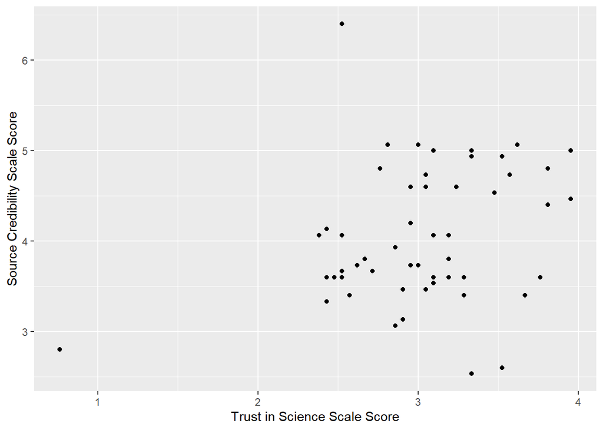

```r
# Scatterplots with labeled axes

ggplot(lab_data, aes(x = TIS_scale, y = SCS_scale)) +
  geom_point() +
  labs(
    x = "Trust in Science Scale Score",
    y = "Source Credibility Scale Score"
  )
```

##### Need for Cognition

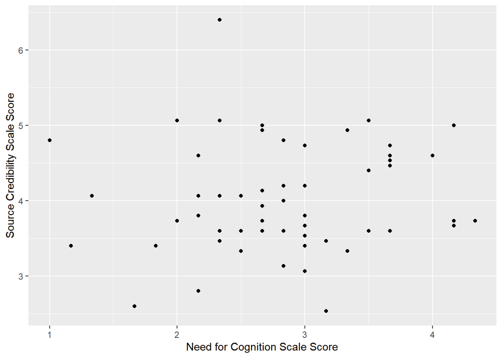

```r
# Scatterplots with labeled axes

ggplot(lab_data, aes(x = NFC_scale, y = SCS_scale)) +
  geom_point() +
  labs(
    x = "Need for Cognition Scale Score",
    y = "Source Credibility Scale Score"
  )
```

The figures suggest little evidence of a strong relationship between the variables.

## **Run the ANOVA**

##### NFC ANOVA

A 2 × 2 between-subjects ANOVA was conducted to examine whether source prestige and need for cognition influenced perceived source credibility.

```r
# 2x2 between-subjects ANOVA predicting source credibility scores
# DV: SCS_scale
# Factors: condition and NFC_msplit

a1_scs_nfc <- afex::aov_ez(
  id = "id",
  dv = "SCS_scale",
  between = c("condition", "NFC_msplit"),
  data = lab_data
)

# Print the ANOVA table
a1_scs_nfc
```

```
Anova Table (Type 3 tests)

Response: SCS_scale
                Effect    df  MSE    F   ges p.value
1            condition 1, 56 0.53 0.74  .013    .392
2           NFC_msplit 1, 56 0.53 0.01 <.001    .925
3 condition:NFC_msplit 1, 56 0.53 0.01 <.001    .942
---
Signif. codes:  0 '***' 0.001 '**' 0.01 '*' 0.05 '+' 0.1 ' ' 1
```

Neither the main effects nor the interaction were statistically significant, indicating that source prestige and need for cognition did not meaningfully influence credibility ratings.

##### TIS ANOVA

A second 2 × 2 between-subjects ANOVA examined whether source prestige and trust in science influenced perceived source credibility.

```r
# 2x2 between-subjects ANOVA predicting source credibility scores
# DV: SCS_scale
# Factors: condition and TIS_msplit

a1_scs <- afex::aov_ez(
  id = "id",
  dv = "SCS_scale",
  between = c("condition", "TIS_msplit"),
  data = lab_data
)

# Print the ANOVA table
a1_scs
```

```
Anova Table (Type 3 tests)

Response: SCS_scale
                Effect    df  MSE    F  ges p.value
1            condition 1, 51 0.56 0.50 .010    .484
2           TIS_msplit 1, 51 0.56 1.25 .024    .269
3 condition:TIS_msplit 1, 51 0.56 0.19 .004    .664
---
Signif. codes:  0 '***' 0.001 '**' 0.01 '*' 0.05 '+' 0.1 ' ' 1
```

No significant main effects or interaction were observed, indicating that trust in science did not moderate the relationship between source prestige and credibility ratings.

### Source Trustworthiness × Need for Cognition Interaction Plot

Estimated marginal means were plotted to visualize the relationship between source prestige and need for cognition.

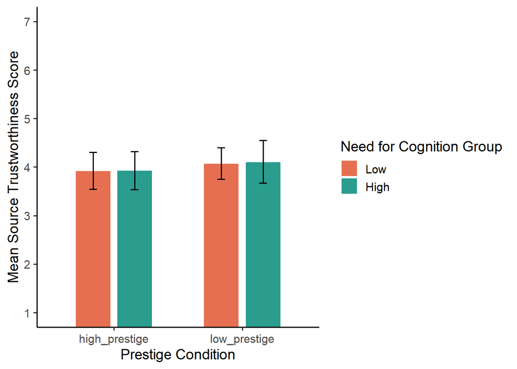

```r
p_source_trustworthiness_nfc_bar <- ggplot(
  as.data.frame(emmeans(a1_scs_nfc, ~ condition * NFC_msplit)),
  aes(
    x = condition,
    y = emmean,
    fill = NFC_msplit
  )
) +
  geom_col(
    position = position_dodge(width = 0.65),
    width = 0.55,
    color = "white"
  ) +
  geom_errorbar(
    aes(
      ymin = lower.CL,
      ymax = upper.CL
    ),
    position = position_dodge(width = 0.65),
    width = 0.12,
    linewidth = 0.7
  ) +
  labs(
    x = "Prestige Condition",
    y = "Mean Source Trustworthiness Score",
    fill = "Need for Cognition Group"
  ) +
  scale_fill_manual(
    values = c(
      "Low" = "#E76F51",
      "High" = "#2A9D8F"
    )
  ) +
  scale_y_continuous(
    breaks = seq(1, 7, 1)
  ) +
  coord_cartesian(
    ylim = c(1, 7)
  ) +
  theme_classic(
    base_size = 14
  )

p_source_trustworthiness_nfc_bar
```

The nearly parallel bars are consistent with the non-significant interaction effect observed in the ANOVA.

### Source Trustworthiness × Trust in Science Interaction Plot

Estimated marginal means were plotted to visualize the relationship between source prestige and trust in science.

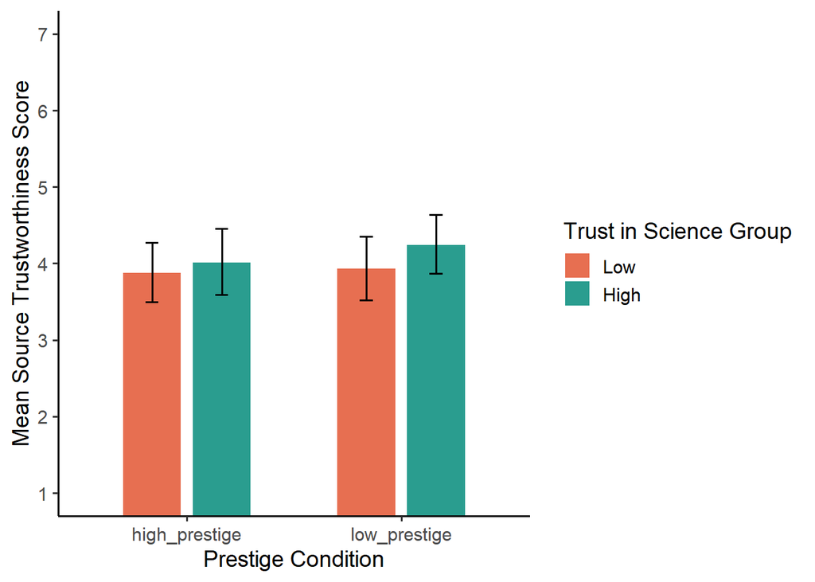

```r
p_source_trustworthiness_tis_bar <- ggplot(
  as.data.frame(emmeans(a1_scs, ~ condition * TIS_msplit)),
  aes(
    x = condition,
    y = emmean,
    fill = TIS_msplit
  )
) +
  geom_col(
    position = position_dodge(width = 0.65),
    width = 0.55,
    color = "white"
  ) +
  geom_errorbar(
    aes(
      ymin = lower.CL,
      ymax = upper.CL
    ),
    position = position_dodge(width = 0.65),
    width = 0.12,
    linewidth = 0.7
  ) +
  labs(
    x = "Prestige Condition",
    y = "Mean Source Trustworthiness Score",
    fill = "Trust in Science Group"
  ) +
  scale_fill_manual(
    values = c(
      "Low" = "#E76F51",
      "High" = "#2A9D8F"
    )
  ) +
  scale_y_continuous(
    breaks = seq(1, 7, 1)
  ) +
  coord_cartesian(
    ylim = c(1, 7)
  ) +
  theme_classic(
    base_size = 14
  )

p_source_trustworthiness_tis_bar
```

The pattern of means suggests little evidence that trust in science changed the effect of source prestige on credibility ratings.

## Summary of Findings

The purpose of this study was to examine whether source prestige influences perceived credibility of health information and whether this relationship is moderated by need for cognition and trust in science. Results showed that source prestige did not significantly affect credibility ratings, and neither need for cognition nor trust in science moderated this relationship. Therefore, none of the study hypotheses were supported.